# Propuesta de Proyecto - Estadistica Descriptiva Multivariada - Exoplanetas NASA

Daniel Alvarado - 145310

2026-09-11

# Introducción y objetivos

Este documento presenta un EDA sobre el conjunto de datos de Exoplanetas de la NASA Exoplanets Archive. El objetivo principal es explorar las características físicas, orbitales y observacionales de los exoplanetas confirmados, relacionando los métodos de descubrimiento, la masa, el radio, las temperaturas y la estructura de los sistemas planetarios

## Variables seleccionadas para el análisis

- discoveryMethod (Cualitativa): Método astrofísico utilizado para descubrir el exoplaneta.
- ttv_flag (Cualitativa): Presencia de Variaciones en el Tiempo de Tránsito (1 = Sí, 0 = No). (Representa si el exoplaneta se ve afectado por interacciones gravitacionales detectables)
- soltype (Cualitativa): Tipo de solución de la publicación de datos. (Representa la procedencia del dato: por ejemplo misión kepler, o una publicación confirmada por un equipo de investigación)
- sy_pnum (Discreta): Número de planetas confirmados en el sistema estelar.
- sy_snum_fct: Número de estrellas en el sistema
- st_spectype_class: Clase Espectral de la Estrella Hospedadora
- disc_facility_top: Instalación/Telescopio de Descubrimiento
- pl_rade (Continua): Radio planetario expresado en radios terrestres ($R_\oplus$).
- pl_bmasse (Continua): Masa planetaria expresada en masas terrestres ($M_\oplus$).
- pl_orbper (Continua): Período orbital en días terrestres.
- pl_eqt (Continua): Temperatura de equilibrio del planeta en Kelvin ($K$).
- st_teff (Continua): Temperatura efectiva de la estrella hospedadora en Kelvin ($K$). (temperatura promedio de la superficie de la estrella)
- sy_dist (Continua): Distancia desde la Tierra al sistema en pársecs ($pc$).

# Carga y preparación de los datos

Cargamos el conjunto de datos desde el archivo CSV NASA_Exoplanet_Archive_Data.csv y aplicamos las transformaciones necesarias mediante la función prepare_exoplanet_data().

```r
# Carga del dataset
raw_data <- read.csv("data_descriptiva_multi/NASA_Exoplanet_Archive_Data.csv", stringsAsFactors = FALSE)

# Preparación y factorización de variables
df <- prepare_exoplanet_data(raw_data)

# Estructura general de las variables seleccionadas
glimpse(df)
```

```
## Rows: 36,418
## Columns: 18
## $ pl_name           <chr> "11 Com b", "11 Com b", "11 Com b", "11 UMi b", "11 …
## $ discoverymethod   <fct> Radial Velocity, Radial Velocity, Radial Velocity, R…
## $ disc_facility     <chr> "Xinglong Station", "Xinglong Station", "Xinglong St…
## $ ttv_flag          <fct> No TTV, No TTV, No TTV, No TTV, No TTV, No TTV, No T…
## $ soltype           <fct> Published Confirmed, Published Confirmed, Published …
## $ sy_snum           <int> 2, 2, 2, 1, 1, 1, 1, 1, 1, 1, 1, 1, 1, 1, 1, 1, 1, 3…
## $ sy_pnum           <int> 1, 1, 1, 1, 1, 1, 1, 1, 1, 2, 2, 2, 2, 2, 2, 2, 2, 1…
## $ st_spectype       <chr> "", "G8 III", "G8 III", "", "", "K4 III", "K0 III", …
## $ pl_rade           <dbl> NA, NA, NA, NA, NA, NA, NA, NA, NA, NA, NA, NA, NA, …
## $ pl_bmasse         <dbl> 5434.7000, 6165.6000, 4914.8985, 4684.8142, 3432.400…
## $ pl_orbper         <dbl> NA, 326.030, 323.210, 516.220, NA, 516.220, 186.760,…
## $ pl_eqt            <dbl> NA, NA, NA, NA, NA, NA, NA, NA, NA, NA, NA, NA, NA, …
## $ st_teff           <dbl> NA, 4742.00, 4874.00, 4213.00, NA, 4340.00, 4888.00,…
## $ sy_dist           <dbl> 93.1846, 93.1846, 93.1846, 125.3210, 125.3210, 125.3…
## $ sy_pnum_fct       <ord> 1, 1, 1, 1, 1, 1, 1, 1, 1, 2, 2, 2, 2, 2, 2, 2, 2, 1…
## $ sy_snum_fct       <fct> 2 Estrellas, 2 Estrellas, 2 Estrellas, 1 Estrella, 1…
## $ st_spectype_class <fct> NA, G, G, NA, NA, K, K, NA, K, K, NA, NA, NA, NA, NA…
## $ disc_facility_top <fct> Otros Observatorios, Otros Observatorios, Otros Obse…
```

```r
str(raw_data)
```

```
## 'data.frame':    36418 obs. of  91 variables:
##  $ pl_name        : chr  "11 Com b" "11 Com b" "11 Com b" "11 UMi b" ...
##  $ hostname       : chr  "11 Com" "11 Com" "11 Com" "11 UMi" ...
##  $ default_flag   : int  0 0 1 1 0 0 1 0 0 0 ...
##  $ sy_snum        : int  2 2 2 1 1 1 1 1 1 1 ...
##  $ sy_pnum        : int  1 1 1 1 1 1 1 1 1 2 ...
##  $ discoverymethod: chr  "Radial Velocity" "Radial Velocity" "Radial Velocity" "Radial Velocity" ...
##  $ disc_year      : int  2007 2007 2007 2009 2009 2009 2008 2008 2008 2002 ...
##  $ disc_facility  : chr  "Xinglong Station" "Xinglong Station" "Xinglong Station" "Thueringer Landessternwarte Tautenburg" ...
##  $ soltype        : chr  "Published Confirmed" "Published Confirmed" "Published Confirmed" "Published Confirmed" ...
##  $ pl_refname     : chr  "https://ui.adsabs.harvard.edu/abs/2011ApJ...737...66K/abstract" "https://ui.adsabs.harvard.edu/abs/2008ApJ...672..553L/abstract" "https://ui.adsabs.harvard.edu/abs/2023arXiv230805343T/abstract" "https://ui.adsabs.harvard.edu/abs/2017AJ....153..136S/abstract" ...
##  $ pl_orbper      : num  NA 326 323 516 NA ...
##  $ pl_orbpererr1  : num  NA 0.32 0.06 3.2 NA 3.25 0.11 NA 0.23 2.5 ...
##  $ pl_orbpererr2  : num  NA -0.32 -0.05 -3.2 NA -3.25 -0.12 NA -0.23 -2.5 ...
##  $ pl_orbperlim   : num  NA 0 0 0 NA 0 0 NA 0 0 ...
```

[output cut: 77 more lines]

# Analisis Univariado

## Variables Cualitativas

### Método de descubrimiento (discoverymethod)

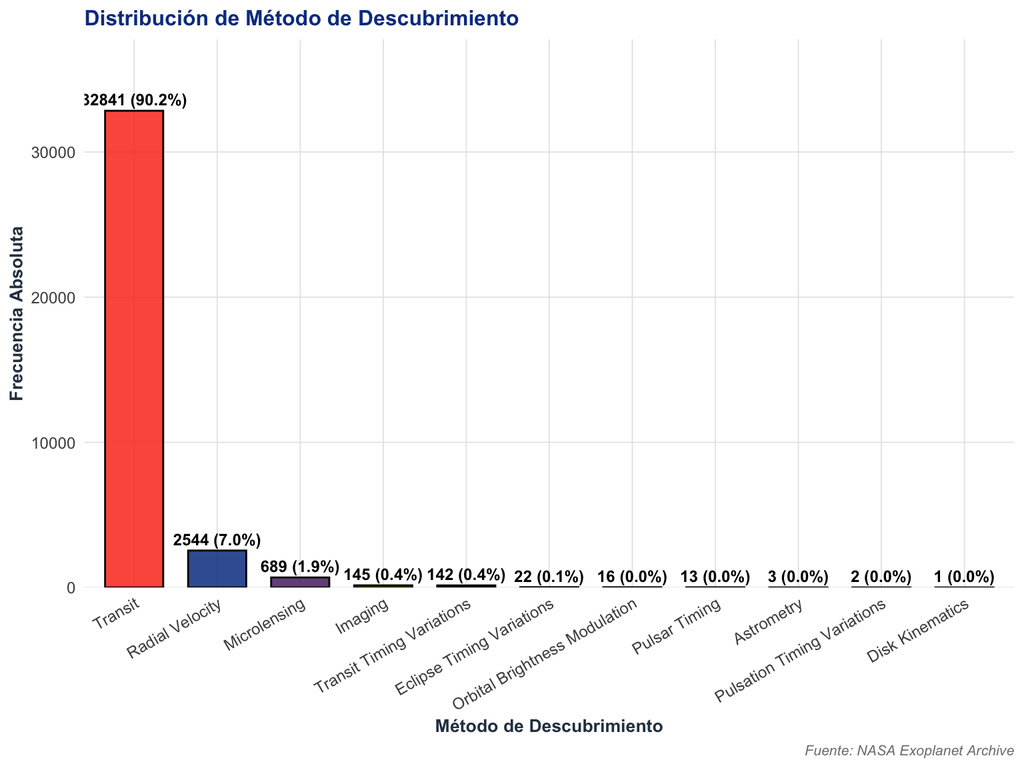

```r
plot_univariate_cuali(df, "discoverymethod", "Método de Descubrimiento")
```

### Variaciones en el Tiempo de Tránsito (ttv_flag)

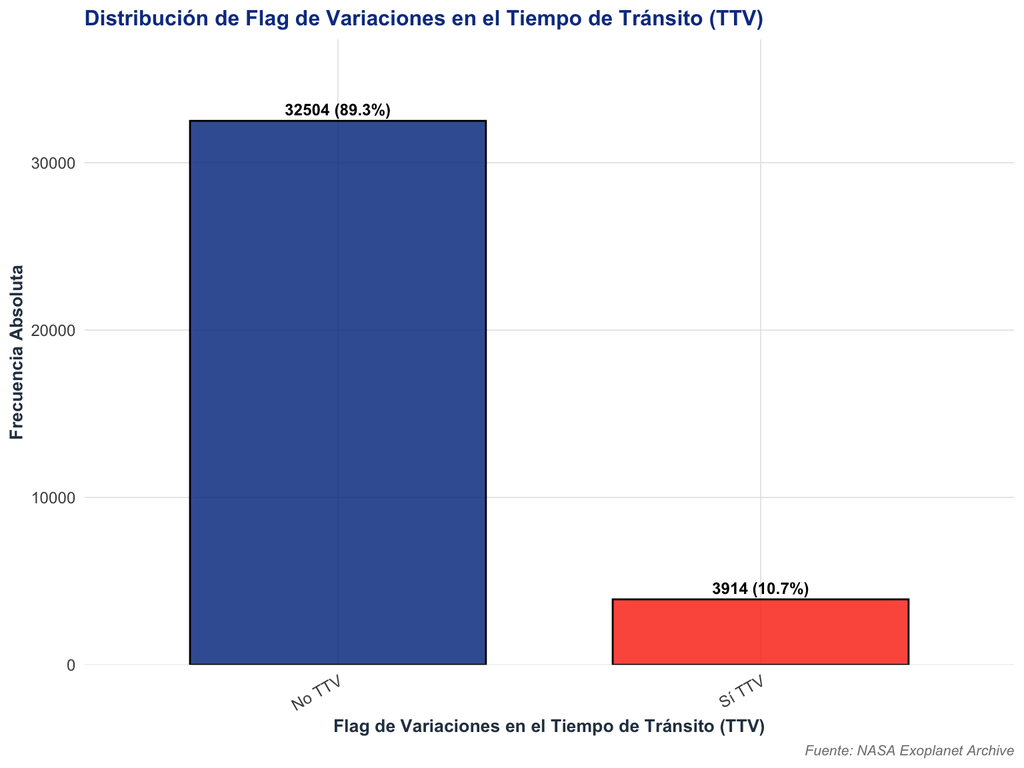

```r
plot_univariate_cuali(df, "ttv_flag", "Flag de Variaciones en el Tiempo de Tránsito (TTV)")
```

### Tipo de Solución (soltype)

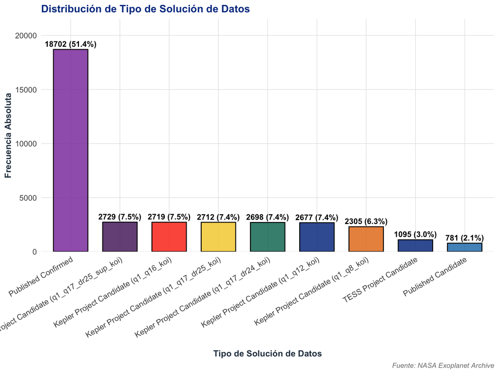

```r
plot_univariate_cuali(df, "soltype", "Tipo de Solución de Datos")
```

### Número de Planetas en el Sistema (sy_pnum_fct) *

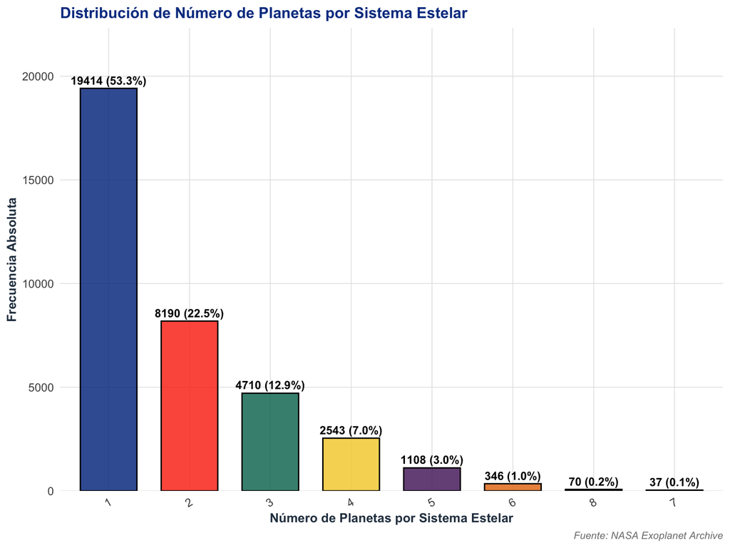

```r
plot_univariate_cuali(df, "sy_pnum_fct", "Número de Planetas por Sistema Estelar")
```

### Clase Espectral de la Estrella (st_spectype_class)

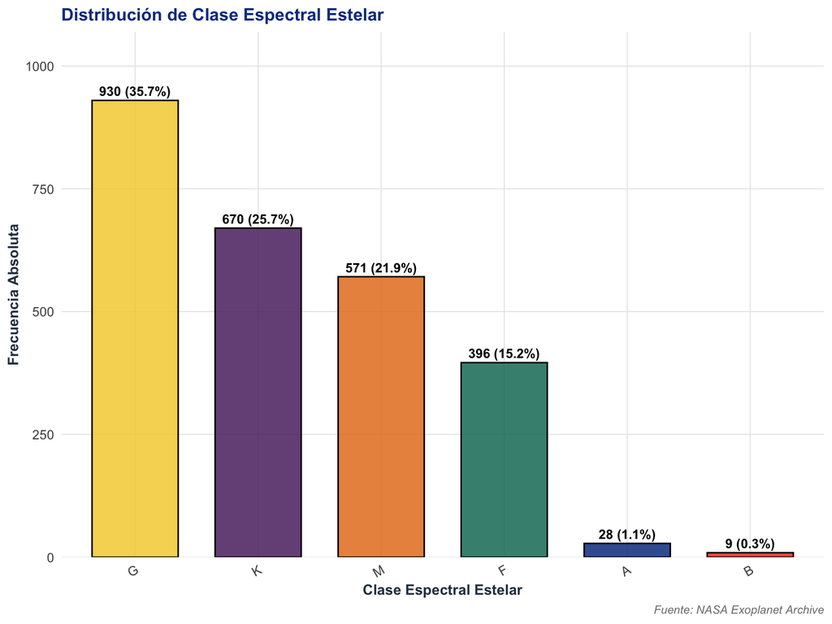

```r
plot_univariate_cuali(df, "st_spectype_class", "Clase Espectral Estelar")
```

### Número de Estrellas en el Sistema (sy_snum_fct)

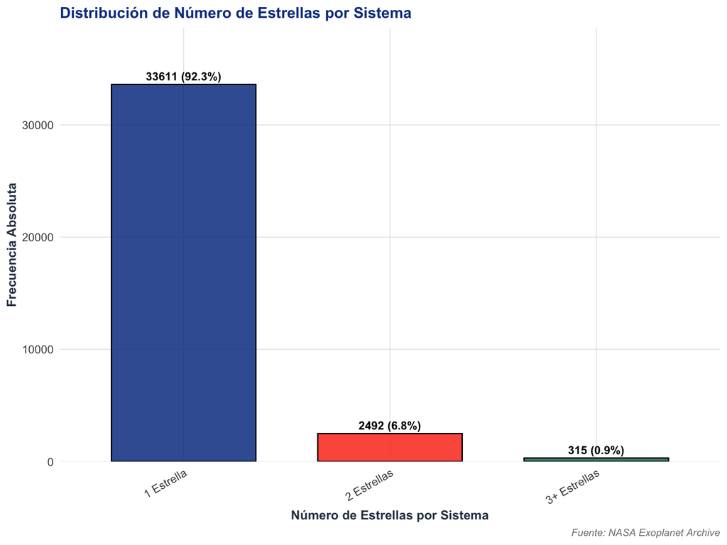

```r
plot_univariate_cuali(df, "sy_snum_fct", "Número de Estrellas por Sistema")
```

### Instalación / Telescopio de Descubrimiento (disc_facility_top)

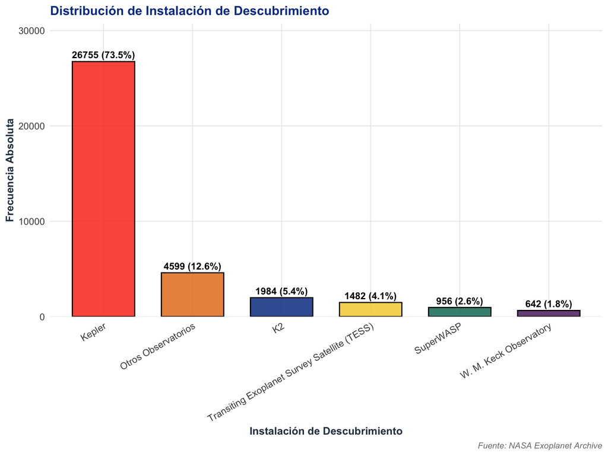

```r
plot_univariate_cuali(df, "disc_facility_top", "Instalación de Descubrimiento")
```

## Variables Cuantitativas

```r
variables_cuanti <- list(
  c("pl_rade", "Radio Planetario (R_E)"),
  c("pl_bmasse", "Masa Planetaria (M_E)"),
  c("pl_orbper", "Período Orbital (Días)"),
  c("pl_eqt", "Temperatura Equilibrio Planetaria (K)"),
  c("st_teff", "Temperatura Efectiva Estelar (K)"),
  c("sy_dist", "Distancia al Sistema (pc)")
)

resumen_cuanti <- map_dfr(variables_cuanti, ~summary_cuanti_table(df, .x[1], .x[2]))

resumen_cuanti %>%
  kable(caption = "Estadísticos Descriptivos de las Variables Cuantitativas", digits = 2) %>%
  kable_styling(bootstrap_options = c("striped", "hover", "condensed", "responsive"))
```

Estadísticos Descriptivos de las Variables Cuantitativas

| Variable | N_Validos | N_Nulos | Media | Mediana | Desv_Est | Mínimo | Q1 | Q3 | Máximo | AD_Stat | AD_p_value |
| --- | --- | --- | --- | --- | --- | --- | --- | --- | --- | --- | --- |
| Radio Planetario (R_E) | 24836 | 11582 | 5.29 | 2.29 | 69.38 | 0.27 | 1.55 | 3.25 | 4.28298e+03 | 8633.04 | < 0.001 |
| Masa Planetaria (M_E) | 6207 | 30211 | 742.55 | 213.26 | 1467.35 | 0.01 | 16.50 | 712.86 | 2.54264e+04 | 919.91 | < 0.001 |
| Período Orbital (Días) | 33247 | 3171 | 13130.46 | 10.33 | 2205981.74 | 0.09 | 4.35 | 26.55 | 4.02000e+08 | 12832.58 | < 0.001 |
| Temperatura Equilibrio Planetaria (K) | 16571 | 19847 | 876.68 | 795.00 | 424.99 | 34.00 | 568.00 | 1097.00 | 4.05000e+03 | 247.73 | < 0.001 |
| Temperatura Efectiva Estelar (K) | 33449 | 2969 | 5458.44 | 5612.00 | 970.67 | 415.00 | 5095.00 | 5953.00 | 5.70000e+04 | 1225.94 | < 0.001 |
| Distancia al Sistema (pc) | 35586 | 832 | 731.25 | 594.46 | 805.15 | 1.30 | 289.83 | 942.48 | 8.80000e+03 | 2279.97 | < 0.001 |

### Radio Planetario (pl_rade)

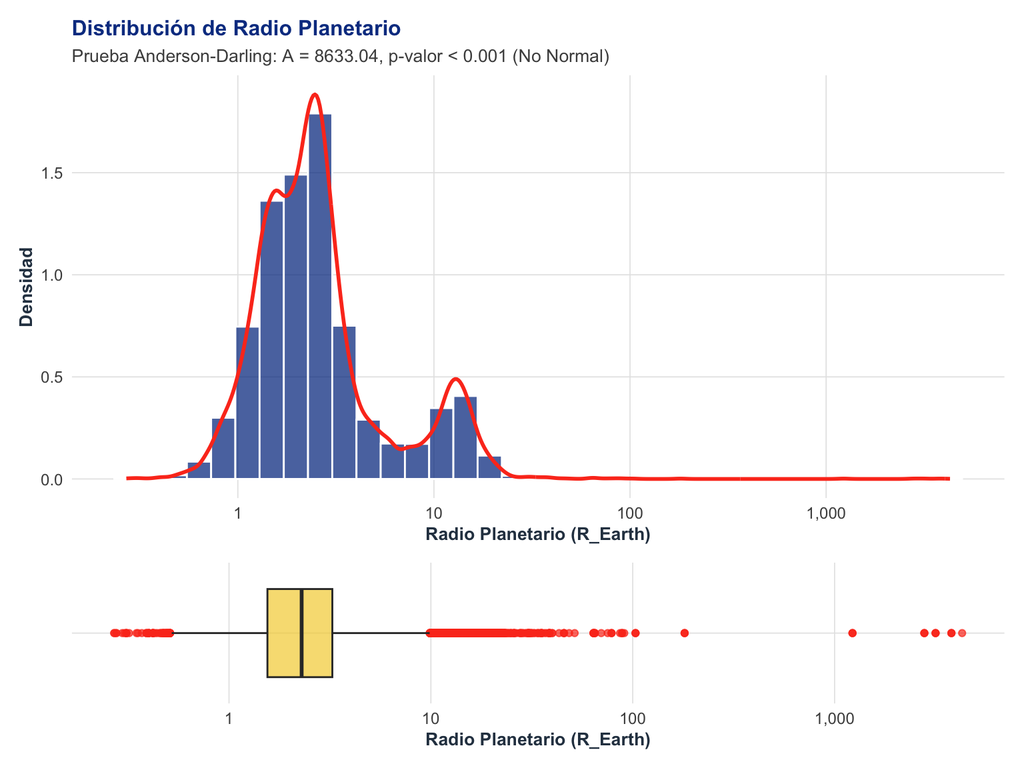

```r
plot_univariate_cuanti(df, "pl_rade", "Radio Planetario", log_scale = TRUE, unit = "R_Earth")
```

### Masa Planetaria (pl_bmasse)

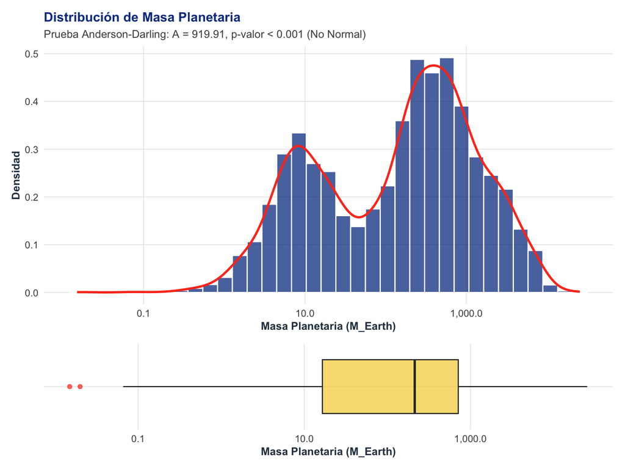

```r
plot_univariate_cuanti(df, "pl_bmasse", "Masa Planetaria", log_scale = TRUE, unit = "M_Earth")
```

### Período Orbital (pl_orbper)

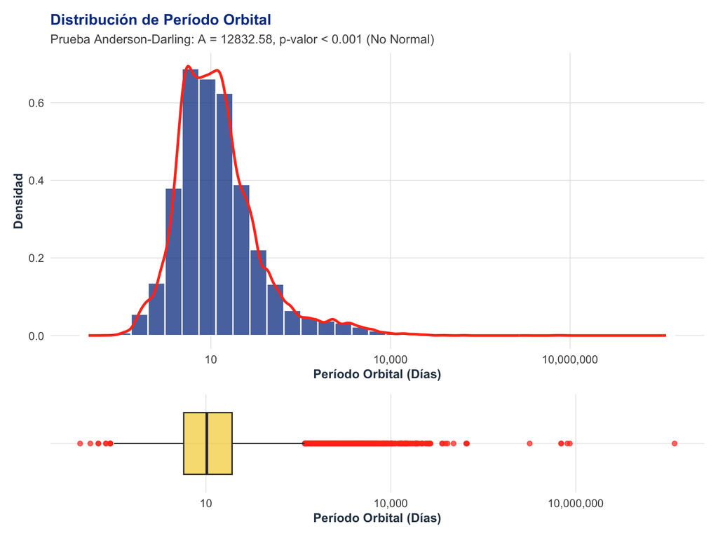

```r
plot_univariate_cuanti(df, "pl_orbper", "Período Orbital", log_scale = TRUE, unit = "Días")
```

### Temperatura de Equilibrio Planetaria (pl_eqt)

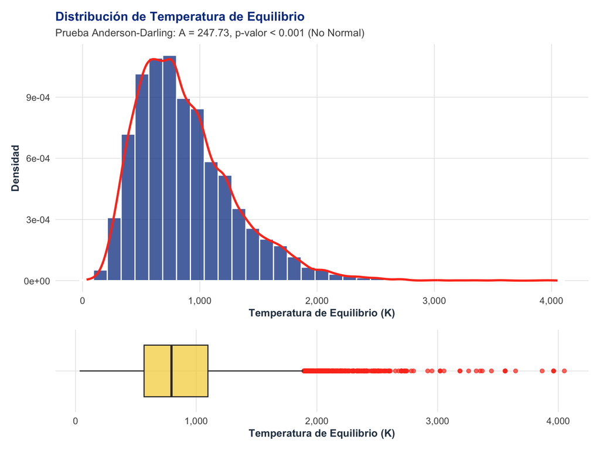

```r
plot_univariate_cuanti(df, "pl_eqt", "Temperatura de Equilibrio", log_scale = FALSE, unit = "K")
```

### Temperatura Efectiva Estelar (st_teff)

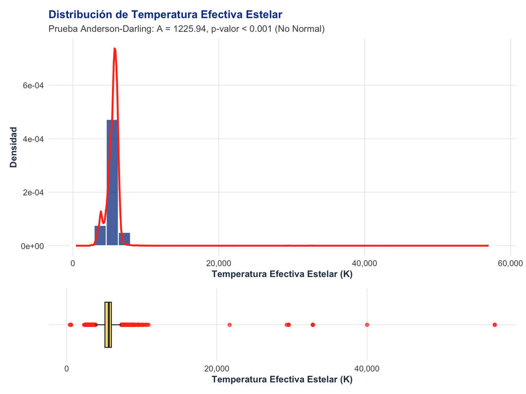

```r
plot_univariate_cuanti(df, "st_teff", "Temperatura Efectiva Estelar", log_scale = FALSE, unit = "K")
```

### Distancia al Sistema (sy_dist)

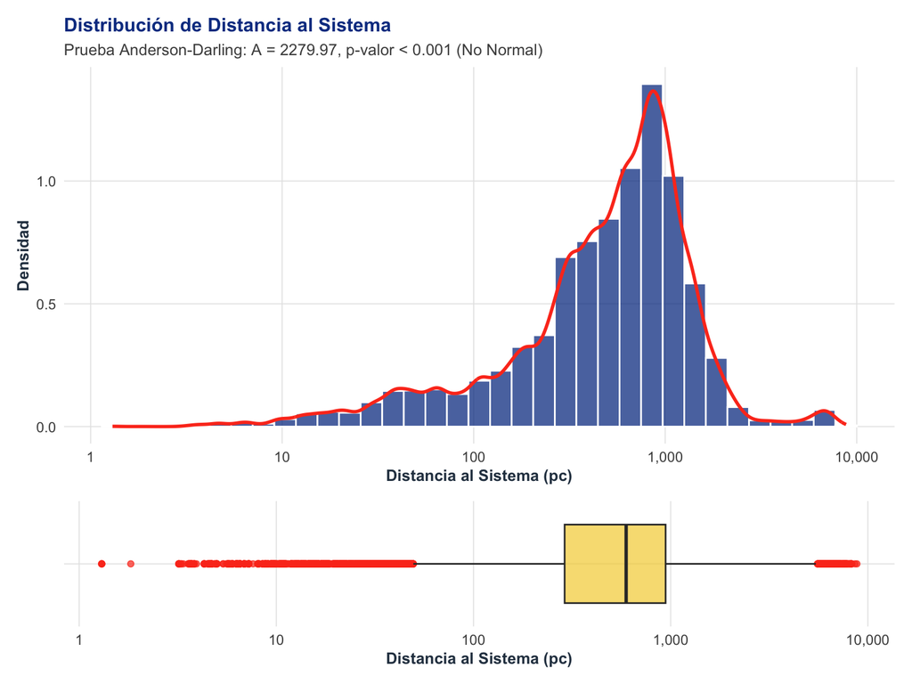

```r
plot_univariate_cuanti(df, "sy_dist", "Distancia al Sistema", log_scale = TRUE, unit = "pc")
```

# Análisis Bivariado

## Cuali Cuali

### Método de Descubrimiento vs Flag TTV

Comparación entre los métodos de descubrimiento y la presencia de variaciones en el tiempo de tránsito.

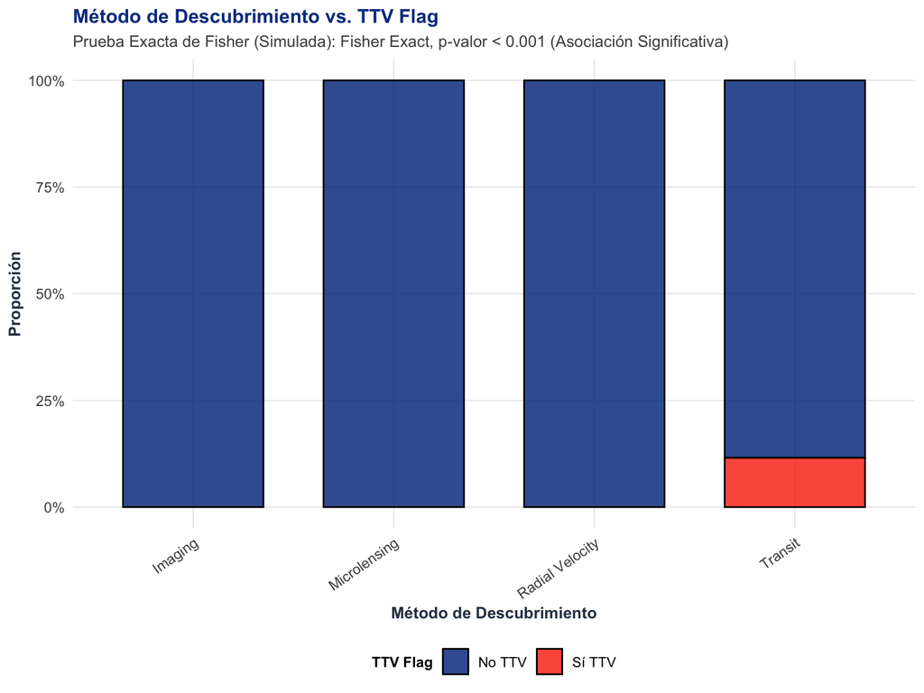

```r
# Filtrar top 4 métodos para visualización más clara
top_methods <- df %>% count(discoverymethod) %>% top_n(4, n) %>% pull(discoverymethod)
df_top_methods <- df %>% filter(discoverymethod %in% top_methods)

plot_cuali_cuali(df_top_methods, "discoverymethod", "ttv_flag", "Método de Descubrimiento", "TTV Flag", position = "fill")
```

### Método de Descubrimiento vs Tipo de Solución (soltype)

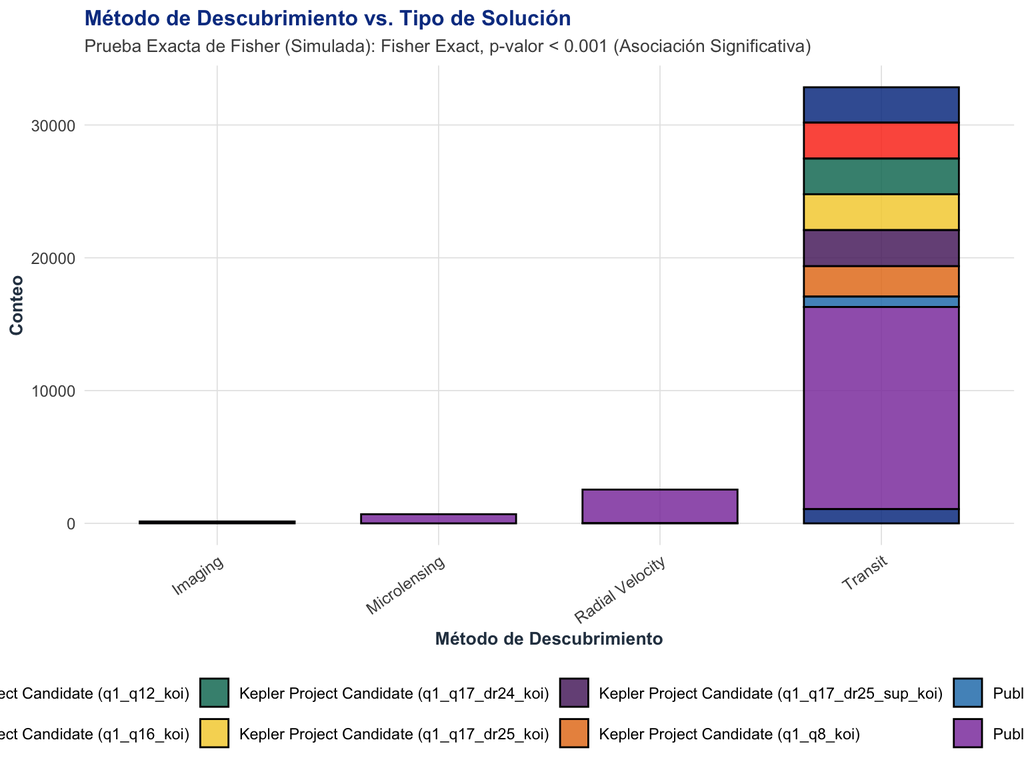

```r
plot_cuali_cuali(df_top_methods, "discoverymethod", "soltype", "Método de Descubrimiento", "Tipo de Solución", position = "stack")
```

### Método de Descubrimiento vs Clase Espectral Estelar

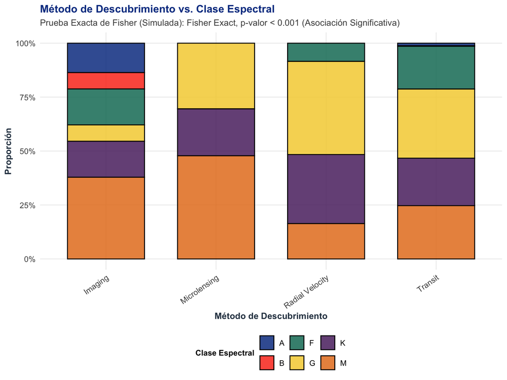

```r
plot_cuali_cuali(df_top_methods, "discoverymethod", "st_spectype_class",
                 "Método de Descubrimiento", "Clase Espectral", position = "fill")
```

### Método de Descubrimiento vs Número de Estrellas

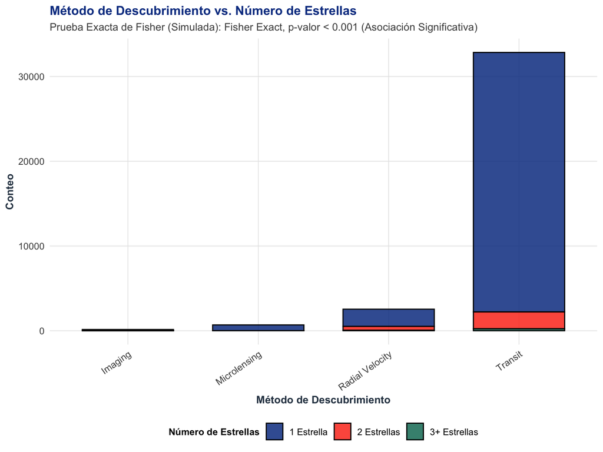

```r
plot_cuali_cuali(df_top_methods, "discoverymethod", "sy_snum_fct",
                 "Método de Descubrimiento", "Número de Estrellas", position = "stack")
```

## Cuali Cuanti

### Tamaño Planetario (pl_rade) según Método de Descubrimiento

Visualización del sesgo de observación (observational bias) de cada técnica sobre el tamaño de los exoplanetas detectados.

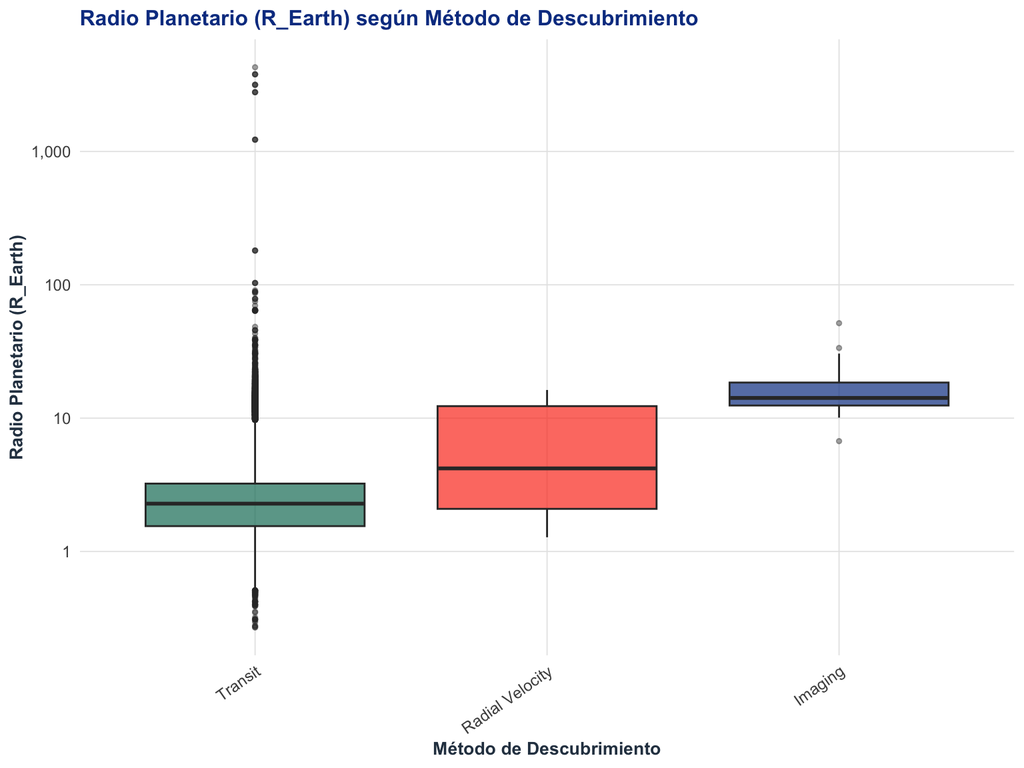

```r
plot_cuali_cuanti(df_top_methods, "discoverymethod", "pl_rade", "Método de Descubrimiento", "Radio Planetario (R_Earth)", log_scale = TRUE)
```

### Período Orbital (pl_orbper) según Número de Planetas (sy_pnum_fct)

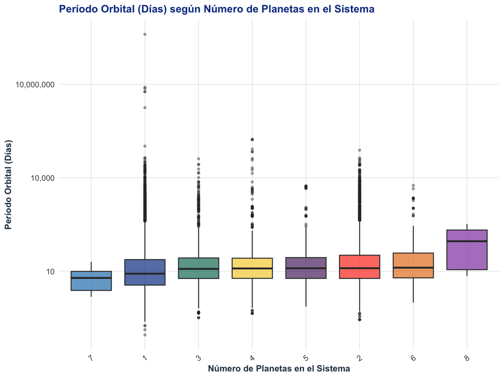

```r
plot_cuali_cuanti(df, "sy_pnum_fct", "pl_orbper", "Número de Planetas en el Sistema", "Período Orbital (Días)", log_scale = TRUE)
```

## Cuanti Cuanti

### Relación Masa-Radio Planetaria (pl_bmasse vs pl_rade)

Estudio de la densidad y composición exoplanetaria.

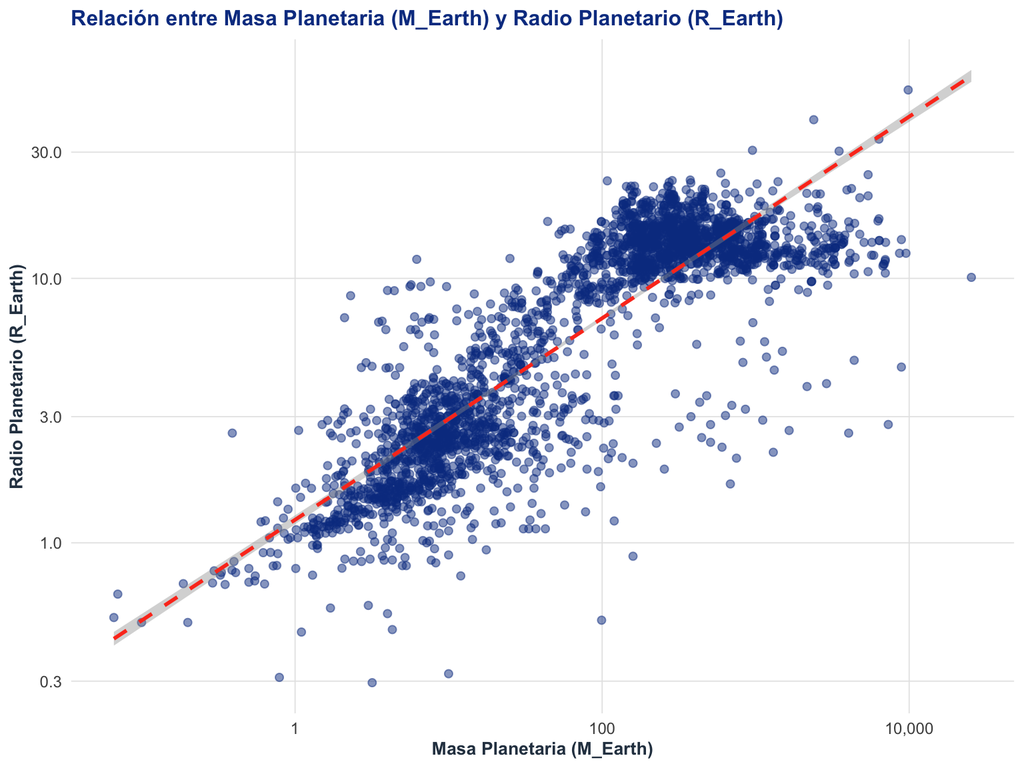

```r
plot_cuanti_cuanti(df, "pl_bmasse", "pl_rade", "Masa Planetaria (M_Earth)", "Radio Planetario (R_Earth)", log_x = TRUE, log_y = TRUE)
```

### Temperatura Estelar vs Temperatura Planetaria (st_teff vs pl_eqt)

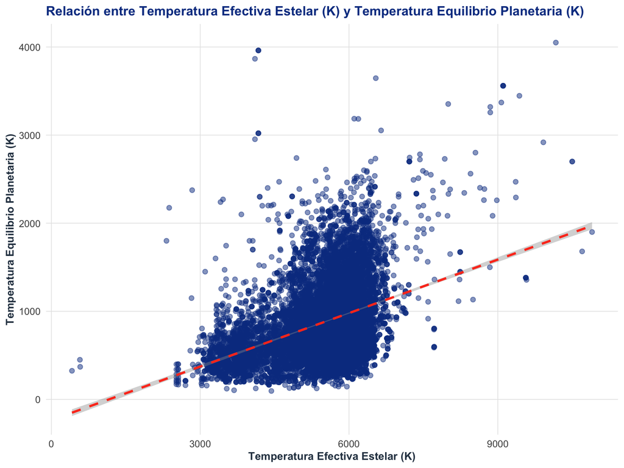

```r
plot_cuanti_cuanti(df, "st_teff", "pl_eqt", "Temperatura Efectiva Estelar (K)", "Temperatura Equilibrio Planetaria (K)", log_x = FALSE, log_y = FALSE)
```

# Matriz de Correlación y Matriz de Varianzas y Covarianzas

En esta sección se analiza la asociación lineal y la dispersión conjunta entre las 6 variables cuantitativas del estudio (`pl_rade`, `pl_bmasse`, `pl_orbper`, `pl_eqt`, `st_teff`, `sy_dist`).

## Matriz de Correlación de Pearson

El coeficiente de correlación de Pearson ($r$) mide la fuerza y dirección de la relación lineal entre cada par de variables en una escala acotada entre $-1$ y $1$.

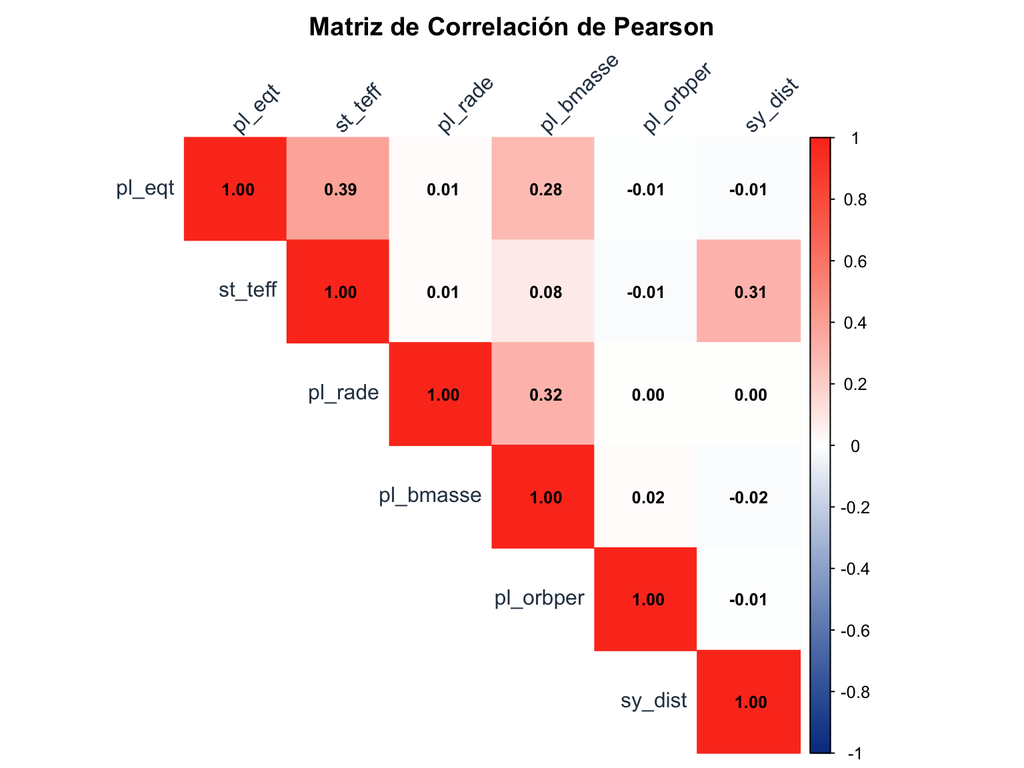

Matriz de Correlación de Pearson

```r
# 1. Gráfico y matriz de correlación en unidades originales
matriz_cor <- plot_pearson_correlation(df, use_log = FALSE)
```

```r
# 2. Tabla de coeficientes r de Pearson
matriz_cor %>%
  round(3) %>%
  knitr::kable(caption = "Coeficientes de Correlación de Pearson (Escala Original)") %>%
  kableExtra::kable_styling(bootstrap_options = c("striped", "hover", "condensed", "responsive"))
```

Coeficientes de Correlación de Pearson (Escala Original)

|  | pl_rade | pl_bmasse | pl_orbper | pl_eqt | st_teff | sy_dist |
| --- | --- | --- | --- | --- | --- | --- |
| pl_rade | 1.000 | 0.319 | 0.001 | 0.010 | 0.011 | 0.003 |
| pl_bmasse | 0.319 | 1.000 | 0.016 | 0.283 | 0.082 | -0.016 |
| pl_orbper | 0.001 | 0.016 | 1.000 | -0.007 | -0.013 | -0.007 |
| pl_eqt | 0.010 | 0.283 | -0.007 | 1.000 | 0.385 | -0.011 |
| st_teff | 0.011 | 0.082 | -0.013 | 0.385 | 1.000 | 0.312 |
| sy_dist | 0.003 | -0.016 | -0.007 | -0.011 | 0.312 | 1.000 |

## Matriz de Varianzas y Covarianzas

La matriz de covarianzas ($\Sigma$) sintetiza la variabilidad individual y la variación conjunta de las variables en sus unidades originales.

```r
# 1. Selección de variables cuantitativas
vars_cuanti <- c("pl_rade", "pl_bmasse", "pl_orbper", "pl_eqt", "st_teff", "sy_dist")

# 2. Extracción de datos numéricos en escala original
df_cov <- df %>%
  select(any_of(vars_cuanti)) %>%
  mutate(across(everything(), as.numeric))

# 3. Cálculo de la matriz de varianzas y covarianzas
matriz_cov <- cov(df_cov, use = "pairwise.complete.obs")

# 4. Presentación tabular de la matriz
matriz_cov %>%
  round(2) %>%
  knitr::kable(caption = "Matriz de Varianzas y Covarianzas (Unidades Originales)") %>%
  kableExtra::kable_styling(bootstrap_options = c("striped", "hover", "condensed", "responsive"))
```

Matriz de Varianzas y Covarianzas (Unidades Originales)

|  | pl_rade | pl_bmasse | pl_orbper | pl_eqt | st_teff | sy_dist |
| --- | --- | --- | --- | --- | --- | --- |
| pl_rade | 4813.83 | 1909.85 | 1.337009e+05 | 373.56 | 604.75 | 85.64 |
| pl_bmasse | 1909.85 | 2153112.62 | 1.181818e+08 | 197439.96 | 191372.65 | -36851.57 |
| pl_orbper | 133700.89 | 118181758.89 | 4.866355e+12 | -9500280.96 | -28040430.43 | -7979981.51 |
| pl_eqt | 373.56 | 197439.96 | -9.500281e+06 | 180619.10 | 130363.47 | -2312.43 |
| st_teff | 604.75 | 191372.65 | -2.804043e+07 | 130363.47 | 942206.28 | 147374.06 |
| sy_dist | 85.64 | -36851.57 | -7.979982e+06 | -2312.43 | 147374.06 | 648274.22 |